# dplyr

## the dplyr package

user-contributed package that has kind of revolutionized working with data in R.

It provides a consistent and simpler interface to do things that you could also do using loops or base functions in R.

It is less flexible than a for loop or `lapply()`, but it is easier to use, and works for the most common data manipulation tasks.

## the dplyr package

`dplyr` is very consistent

it assumes that you are starting with a dataframe, doing something to that dataframe, and finishing with a different dataframe.

Many of the base R functions operate on atomic vectors, which makes it more complicated to apply them to dataframes.)

`dplyr` introduces a series of simple 'verbs' that describe many common data manipulation tasks.

## Challenge

We will use a dataset on student loans in public and private universities.

Read in this dataset called DMV_2014_Q3_Undergrad_DirectLoans.txt and save it to a variable called `loans`.

## The basic dplyr verbs

There are a few basic functions in `dplyr`

The first argument to these functions is always the dataframe that you want to manipulate.

Within these function calls, you can refer to the names of columns in the dataframe without quotation marks and without the usual `$` syntax.

```r
library(dplyr)
```

## `filter()`

This function selects a subset of rows meeting some criterion. Note that the result is a dataframe.

```r
filter(loans, School=="GEORGE WASHINGTON UNIVERSITY")
```

```
##                         School State      School_Type SubsidizedDL
## 1 GEORGE WASHINGTON UNIVERSITY    DC PrivateNonprofit      7463145
##   UNSubsidizedDL
## 1        5913027
```

## `arrange()`

This function is like the "sort" function in MS Excel. You simply provide a list of column names to sort by:

```r
arrange(loans, State, SubsidizedDL)
```

```
##                                                                   School
## 1                                 NATIONAL CONSERVATORY OF DRAMATIC ARTS
## 2                                             TECHNICAL LEARNING CENTERS
## 3                                               BENNETT CAREER INSTITUTE
## 4                                                        RADIANS COLLEGE
## 5                                     CORCORAN COLLEGE OF ART AND DESIGN
## 6                                             CAREER TECHNICAL INSTITUTE
## 7                                                   GALLAUDET UNIVERSITY
## 8                                                        TRINITY COLLEGE
## 9                                         CATHOLIC UNIVERSITY OF AMERICA
## 10                                                 GEORGETOWN UNIVERSITY
## 11                                UNIVERSITY OF THE DISTRICT OF COLUMBIA
## 12                                                   AMERICAN UNIVERSITY
## 13                                          GEORGE WASHINGTON UNIVERSITY
## 14                                                     HOWARD UNIVERSITY
```

[output cut: 407 more lines]

```r
arrange(loans, State, desc(SubsidizedDL))
```

```
##                                                                   School
## 1                                                     STRAYER UNIVERSITY
## 2                                                      HOWARD UNIVERSITY
## 3                                           GEORGE WASHINGTON UNIVERSITY
## 4                                                    AMERICAN UNIVERSITY
## 5                                 UNIVERSITY OF THE DISTRICT OF COLUMBIA
## 6                                                  GEORGETOWN UNIVERSITY
## 7                                         CATHOLIC UNIVERSITY OF AMERICA
## 8                                                        TRINITY COLLEGE
## 9                                                   GALLAUDET UNIVERSITY
## 10                                            CAREER TECHNICAL INSTITUTE
## 11                                    CORCORAN COLLEGE OF ART AND DESIGN
## 12                                                       RADIANS COLLEGE
## 13                                              BENNETT CAREER INSTITUTE
## 14                                            TECHNICAL LEARNING CENTERS
```

[output cut: 407 more lines]

## `select()`

This function pulls out columns of interest. You can select ranges of columns using the `:` operator syntax. (Note: usually this only works with numeric data, but this is a special usage defined in the `dplyr` package)

```r
select(loans, State, SubsidizedDL)
```

```
##     State SubsidizedDL
## 1      DC      6213538
## 2      DC      3619502
## 3      DC      3850272
## 4      DC       679602
## 5      DC      7463145
## 6      DC      3824260
## 7      DC      9414766
## 8      DC     22490396
## 9      DC      2522961
## 10     DC           NA
## 11     DC       356355
## 12     DC           NA
## 13     DC        40812
## 14     DC       416911
```

[output cut: 196 more lines]

```r
select(loans, -State, -SubsidizedDL)
```

```
##                                                                   School
## 1                                                    AMERICAN UNIVERSITY
## 2                                         CATHOLIC UNIVERSITY OF AMERICA
## 3                                 UNIVERSITY OF THE DISTRICT OF COLUMBIA
## 4                                                   GALLAUDET UNIVERSITY
## 5                                           GEORGE WASHINGTON UNIVERSITY
## 6                                                  GEORGETOWN UNIVERSITY
## 7                                                      HOWARD UNIVERSITY
## 8                                                     STRAYER UNIVERSITY
## 9                                                        TRINITY COLLEGE
## 10                                           WESLEY THEOLOGICAL SEMINARY
## 11                                    CORCORAN COLLEGE OF ART AND DESIGN
## 12                                            DOMINICAN HOUSE OF STUDIES
## 13                                NATIONAL CONSERVATORY OF DRAMATIC ARTS
## 14                                            CAREER TECHNICAL INSTITUTE
```

[output cut: 407 more lines]

```r
select(loans, State:SubsidizedDL)
```

```
##     State      School_Type SubsidizedDL
## 1      DC PrivateNonprofit      6213538
## 2      DC PrivateNonprofit      3619502
## 3      DC           Public      3850272
## 4      DC PrivateNonprofit       679602
## 5      DC PrivateNonprofit      7463145
## 6      DC PrivateNonprofit      3824260
## 7      DC PrivateNonprofit      9414766
## 8      DC      Proprietary     22490396
## 9      DC PrivateNonprofit      2522961
## 10     DC PrivateNonprofit           NA
## 11     DC PrivateNonprofit       356355
## 12     DC PrivateNonprofit           NA
## 13     DC PrivateNonprofit        40812
## 14     DC      Proprietary       416911
```

[output cut: 196 more lines]

## `distinct()`

This function extracts the distinct rows. It is most useful when combined with select

```r
distinct(loans)
```

```
##                                                                   School
## 1                                                    AMERICAN UNIVERSITY
## 2                                         CATHOLIC UNIVERSITY OF AMERICA
## 3                                 UNIVERSITY OF THE DISTRICT OF COLUMBIA
## 4                                                   GALLAUDET UNIVERSITY
## 5                                           GEORGE WASHINGTON UNIVERSITY
## 6                                                  GEORGETOWN UNIVERSITY
## 7                                                      HOWARD UNIVERSITY
## 8                                                     STRAYER UNIVERSITY
## 9                                                        TRINITY COLLEGE
## 10                                           WESLEY THEOLOGICAL SEMINARY
## 11                                    CORCORAN COLLEGE OF ART AND DESIGN
## 12                                            DOMINICAN HOUSE OF STUDIES
## 13                                NATIONAL CONSERVATORY OF DRAMATIC ARTS
## 14                                            CAREER TECHNICAL INSTITUTE
```

[output cut: 407 more lines]

```r
distinct(select(loans, State, School_Type))
```

```
##   State      School_Type
## 1    DC PrivateNonprofit
## 2    DC           Public
## 3    DC      Proprietary
## 4    MD PrivateNonprofit
## 5    MD           Public
## 6    MD      Proprietary
## 7    VA PrivateNonprofit
## 8    VA           Public
## 9    VA      Proprietary
```

## `mutate()`

Adds new columns that are some function of existing columns

```r
mutate(loans, Total_Loans = SubsidizedDL + UNSubsidizedDL)
```

```
##                                                                   School
## 1                                                    AMERICAN UNIVERSITY
## 2                                         CATHOLIC UNIVERSITY OF AMERICA
## 3                                 UNIVERSITY OF THE DISTRICT OF COLUMBIA
## 4                                                   GALLAUDET UNIVERSITY
## 5                                           GEORGE WASHINGTON UNIVERSITY
## 6                                                  GEORGETOWN UNIVERSITY
## 7                                                      HOWARD UNIVERSITY
## 8                                                     STRAYER UNIVERSITY
## 9                                                        TRINITY COLLEGE
## 10                                           WESLEY THEOLOGICAL SEMINARY
## 11                                    CORCORAN COLLEGE OF ART AND DESIGN
## 12                                            DOMINICAN HOUSE OF STUDIES
## 13                                NATIONAL CONSERVATORY OF DRAMATIC ARTS
## 14                                            CAREER TECHNICAL INSTITUTE
```

[output cut: 407 more lines]

## `rowwise()`

Mutate works as expected when you want to manipulate whole columns at once, but sometimes you want to do something on a row-by-row basis.

For example: this code doesn't work as you might expect

```r
myDF <- data.frame(x=c(1,2,3), y=c(10, 11, 12))
mutate(myDF, sum=sum(x, y))
```

```
##   x  y sum
## 1 1 10  39
## 2 2 11  39
## 3 3 12  39
```

## `rowwise()`

But this code computes the sum on a row-by-row basis, as you might expect

```r
myDF <- data.frame(x=c(1,2,3), y=c(10, 11, 12))
mutate(rowwise(myDF), sum=sum(x, y))
```

```
## Source: local data frame [3 x 3]
## Groups: <by row>
##
## # A tibble: 3 × 3
##       x     y   sum
##   <dbl> <dbl> <dbl>
## 1     1    10    11
## 2     2    11    13
## 3     3    12    15
```

## `summarise()`

Summarizes data into a single row. This may seem not that useful, but it will become useful when we start grouping data.

```r
summarise(loans, meanSubDL = mean(SubsidizedDL, na.rm=TRUE))
```

```
##   meanSubDL
## 1   2607474
```

## Grouping Data

These functions above get really powerful when you start grouping data based on factors in your dataset.

## `group_by()`

```r
groupedLoans <- group_by(loans, State)
summarise(groupedLoans, meanSubDL = mean(SubsidizedDL, na.rm=TRUE))
```

```
## # A tibble: 3 × 2
##    State meanSubDL
##   <fctr>     <dbl>
## 1     DC   4094947
## 2     MD   2132025
## 3     VA   2730055
```

## Chaining operations

`dplyr` also provides a way of chaining together complicated operations with the `%>%` operator.

This prevents having to save intermediate steps, or to have a complicated series of nested functions.

Note that the resulting dataframe from each step is passed as the first argument to the next function in the chain.

## Chaining operations

```r
group_by(loans, School_Type) %>%
  mutate(Total_Loans = SubsidizedDL + UNSubsidizedDL) %>%
  select(-State) %>%
  summarise(mean_total_loans = mean(Total_Loans, na.rm=TRUE))
```

```
## # A tibble: 3 × 2
##        School_Type mean_total_loans
##             <fctr>            <dbl>
## 1 PrivateNonprofit          5115076
## 2      Proprietary          1796278
## 3           Public         10315783
```

## Chaining works with non-`dplyr()` functions too

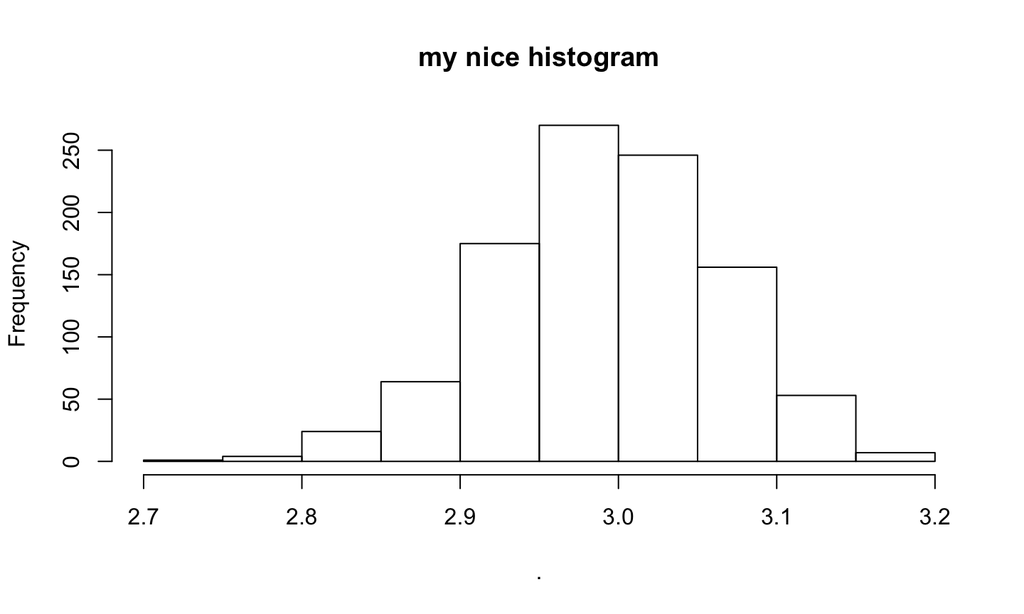

```r
#chained syntax
rnorm(1000, mean=20, sd=1.4) %>% log %>% hist(main="my nice histogram")
```

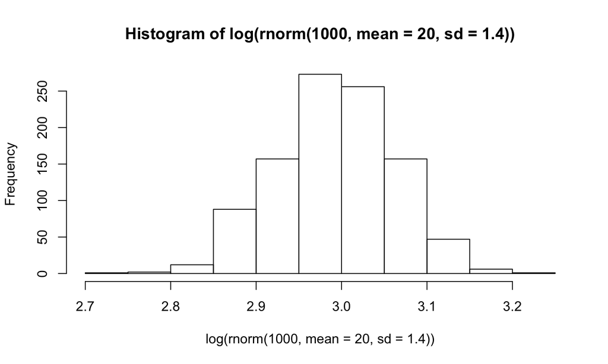

```r
#compare with nested function calls

hist(log(rnorm(1000, mean=20, sd=1.4)))
```

## `do()`

do anything to grouped data

```r
linearModels <- loans %>% group_by(State) %>%
  do(regression=lm(UNSubsidizedDL~SubsidizedDL, data=.))
linearModels
```

```
## Source: local data frame [3 x 2]
## Groups: <by row>
##
## # A tibble: 3 × 2
##    State regression
## * <fctr>     <list>
## 1     DC   <S3: lm>
## 2     MD   <S3: lm>
## 3     VA   <S3: lm>
```

## `do()`

```r
linearModels <- loans %>% group_by(State) %>%
  do(regression=lm(UNSubsidizedDL~SubsidizedDL, data=.))
linearModels
```

[output not shown]

```r
linearModels %>%
  summarize(sum=summary(regression)$r.squared)
```

```
## # A tibble: 3 × 1
##         sum
##       <dbl>
## 1 0.9386189
## 2 0.9581966
## 3 0.9828069
```

## Challenge

Using the `diamonds` dataset that is built in to the `ggplot2` package:

- calculate the mean price of diamonds for each of the different clarity ratings
- create a new column called `volume` that is the product of x, y and z
- plot `volume` against `carat`

## More info

A more complete introduction is available in the [`dplyr` vignette](http://cran.rstudio.com/web/packages/dplyr/vignettes/introduction.html)

More info on `magrittr` [can be found here](http://cran.r-project.org/web/packages/magrittr/vignettes/magrittr.html).